# Dissecting individual loci with eQTLs

### 4.3.2 Figures

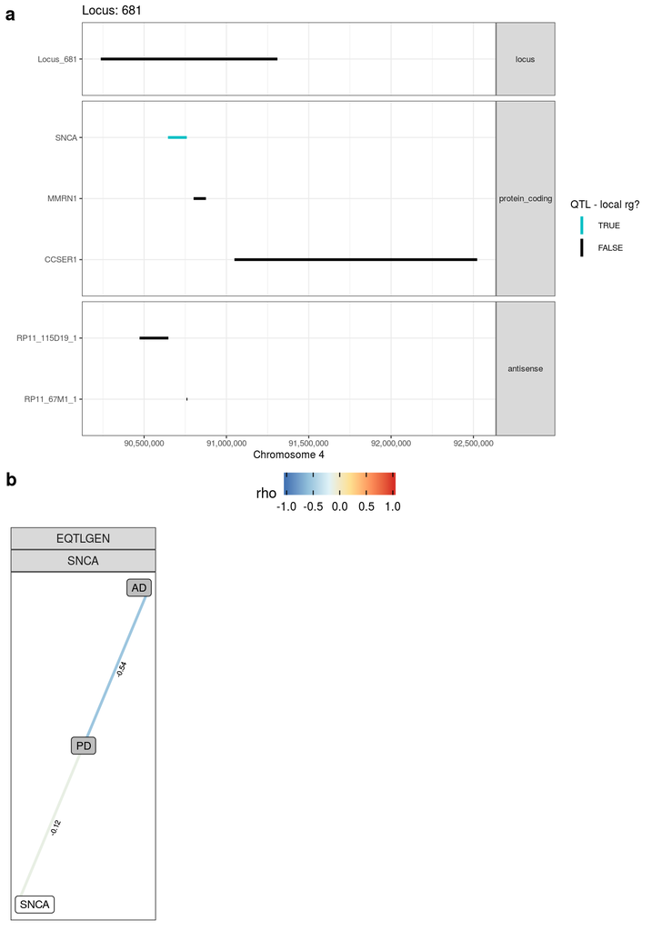

Figure 4.4: (a) Locus plot. Gene loci with a significant bivariate local genetic correlation between a disease phenotype and eQTL are highlighted in blue (FDR-corrected p < 0.05). (b) Edge diagrams for gene loci where a significant bivariate local genetic correlation was observed between a disease phenotype and eQTL (FDR-corrected p < 0.05). Edges display the standardised coefficient for genetic correlation (rho) for significant bivariate local genetic correlations, with negative and positive correlations indicated by blue and red colour, respectively. GWAS and eQTL nodes are indicated by grey and white fill, respectively.

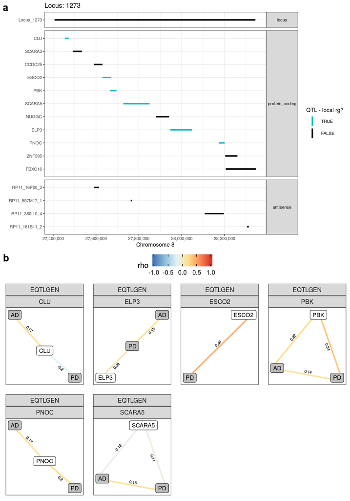

Figure 4.5: (a) Locus plot. Gene loci with a significant bivariate local genetic correlation between a disease phenotype and eQTL are highlighted in blue (FDR-corrected p < 0.05). (b) Edge diagrams for gene loci where a significant bivariate local genetic correlation was observed between a disease phenotype and eQTL (FDR-corrected p < 0.05). Edges display the standardised coefficient for genetic correlation (rho) for significant bivariate local genetic correlations, with negative and positive correlations indicated by blue and red colour, respectively. GWAS and eQTL nodes are indicated by grey and white fill, respectively.

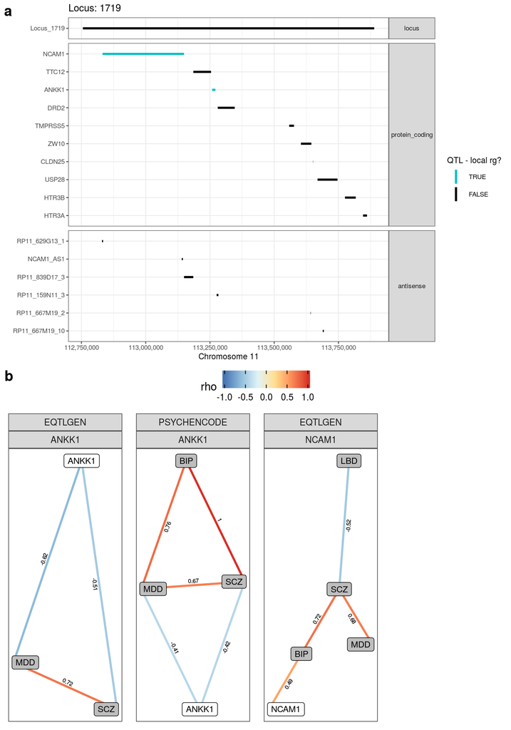

Figure 4.6: (a) Locus plot. Gene loci with a significant bivariate local genetic correlation between a disease phenotype and eQTL are highlighted in blue (FDR-corrected p < 0.05). (b) Edge diagrams for gene loci where a significant bivariate local genetic correlation was observed between a disease phenotype and eQTL (FDR-corrected p < 0.05). Edges display the standardised coefficient for genetic correlation (rho) for significant bivariate local genetic correlations, with negative and positive correlations indicated by blue and red colour, respectively. GWAS and eQTL nodes are indicated by grey and white fill, respectively.

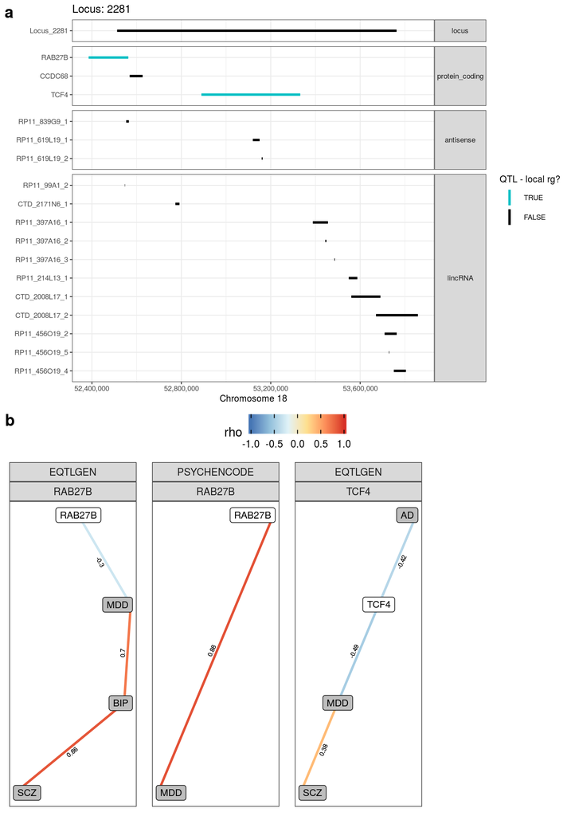

Figure 4.7: (a) Locus plot. Gene loci with a significant bivariate local genetic correlation between a disease phenotype and eQTL are highlighted in blue (FDR-corrected p < 0.05). (b) Edge diagrams for gene loci where a significant bivariate local genetic correlation was observed between a disease phenotype and eQTL (FDR-corrected p < 0.05). Edges display the standardised coefficient for genetic correlation (rho) for significant bivariate local genetic correlations, with negative and positive correlations indicated by blue and red colour, respectively. GWAS and eQTL nodes are indicated by grey and white fill, respectively.

```r
ld_blocks <-
  bivar_fdr$ld_block %>% unique() %>% sort()

qtl_genes <-
  bivar_fdr %>%
  dplyr::filter(str_detect(phen2, "ENSG")) %>%
  .[["gene_locus"]] %>%
  unique()

bivar_list <-
  setNames(
    bivar_fdr %>%
      dplyr::group_split(ld_block),
    nm =
      str_c("locus_", ld_blocks)
  )

ref <- import("/data/references/ensembl/gtf_gff3/v87/Homo_sapiens.GRCh37.87.gtf")
ref <- ref %>% keepSeqlevels(c(1:22), pruning.mode = "coarse")
ref <- ref[ref$type == "gene"]

loci_gr <-
  LAVA::read.loci(here::here("results", "01_input_prep", "gwas_filtered.loci")) %>%
  dplyr::rename(locus = LOC) %>%
  dplyr::filter(locus %in% bivar_fdr$ld_block) %>%
  GenomicRanges::makeGRangesFromDataFrame(
    .,
    keep.extra.columns = TRUE,
    ignore.strand = TRUE,
    seqinfo = NULL,
    seqnames.field = "CHR",
    start.field = "START",
    end.field = "STOP"
  )

fig_list <- vector(mode = "list", length = length(ld_blocks))

for(block in ld_blocks){

  locus_plot <-
    plot_locus(
    locus_gr = loci_gr[loci_gr$locus == block],
    ref = ref,
    highlight_gene = qtl_genes,
    highlight_gene_label = "QTL - local rg?"
    )

  edge_plot <-
    plot_qtl_edge_diagram(
          bivar_corr_qtl = bivar_list[[str_c("locus_", block)]],
          phen = fct_disease,
          seed = 89
        )

  if(length(edge_plot)/4 >=2){

    height <- c(1,3.5)

  } else{

    height <- c(1,1)
  }

  fig_list[[which(ld_blocks == block)]] <-
    ggpubr::ggarrange(
      locus_plot,
      ggpubr::ggarrange(
        plotlist = edge_plot,
        ncol = 4,
        nrow = ceiling(length(edge_plot)/4),
        common.legend = TRUE,
        legend = "top"
      ),
      ncol = 1,
      labels = letters[1:2],
      heights = height
    )

    names(fig_list)[which(ld_blocks == block)] <- str_c("locus_", block)

}

fig_list[1:4]
```

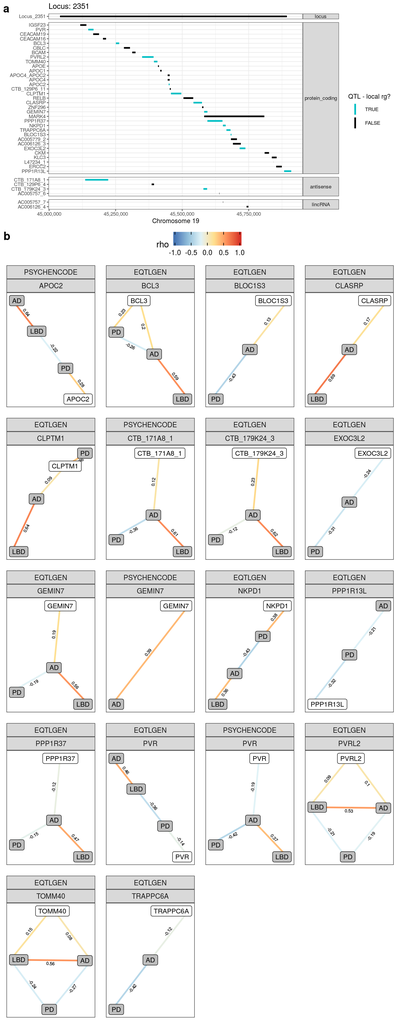

Figure 4.8: (a) Locus plot. Gene loci with a significant bivariate local genetic correlation between a disease phenotype and eQTL are highlighted in blue (FDR-corrected p < 0.05). (b) Edge diagrams for gene loci where a significant bivariate local genetic correlation was observed between a disease phenotype and eQTL (FDR-corrected p < 0.05). Edges display the standardised coefficient for genetic correlation (rho) for significant bivariate local genetic correlations, with negative and positive correlations indicated by blue and red colour, respectively. GWAS and eQTL nodes are indicated by grey and white fill, respectively.

```r
fig_list[5]
```

## 4.4 Phenotype correlations at gene locus level using stringent bonferroni multiple test correction

### 4.4.1 Text

- Of the 42 eQTL-GWAS bivariate correlations observed using the lenient FDR correction, 19 survived Bonferroni correction.
- Some of these included:
  - Locus 681
    - Negative $r_{g}$ between AD and PD and between PD and eQTLGen-derived *SNCA* eQTLs.
  - Locus 1273
    - Positive local $r_{g}$ between PD and eQTLGen-derived *ESCO2*, *PBK* and *PNOC* eQTLs.
  - Locus 1719
    - Positive local $r_{g}$ between MDD and SCZ and negative local $r_{g}$ between both neuropsychiatric disorders and eQTLGen-derived *ANKK1* eQTLs.
    - Positve local $r_{g}$ between BIP and eQTLGen-derived *NCAM1* eQTLs.
  - Locus 2281
    - Positive local $r_{g}$ between MDD and PsychENCODE-derived *RAB27B* eQTLs.
    - Negative local $r_{g}$ between MDD and eQTLGen-derived *TCF4* eQTLs.
  - Locus 2351 (of the 22 eQTL-GWAS bivariate correlations observed using the lenient FDR correction, 10 survived Bonferroni correction)
    - Positive local $r_{g}$ between AD and eQTLGen- and PsychENCODE-derived *GEMIN7* eQTLs.
    - Positive local $r_{g}$ between AD and eQTLGen-derived *PVRL2* eQTLs.

### 4.4.2 Figures

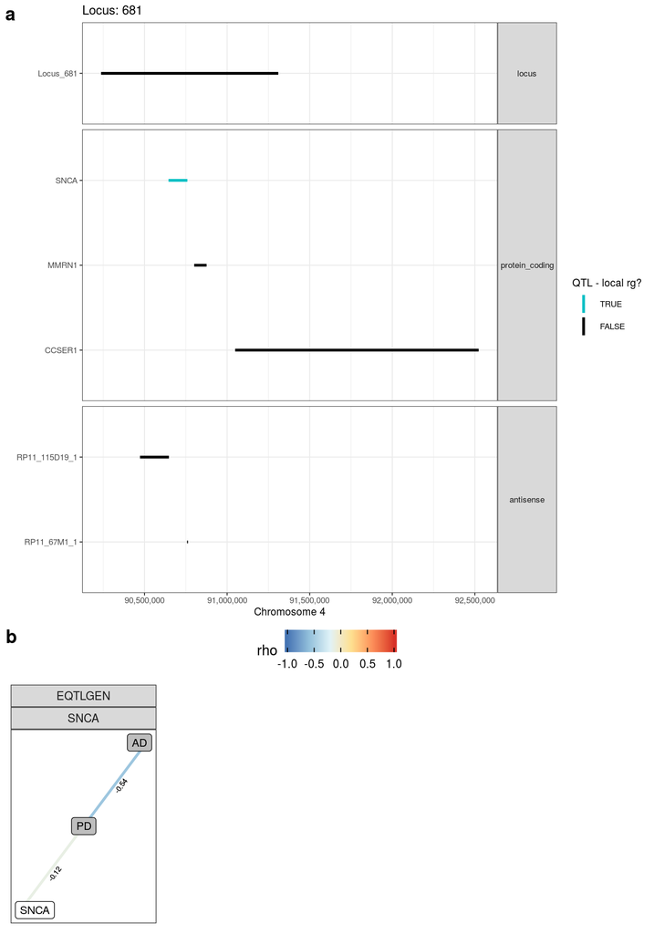

Figure 4.9: (a) Locus plot. Gene loci with a significant bivariate local genetic correlation between a disease phenotype and eQTL are highlighted in blue (Bonferroni-corrected p < 0.05). (b) Edge diagrams for gene loci where a significant bivariate local genetic correlation was observed between a disease phenotype and eQTL (Bonferroni-corrected p < 0.05). Edges display the standardised coefficient for genetic correlation (rho) for significant bivariate local genetic correlations, with negative and positive correlations indicated by blue and red colour, respectively. GWAS and eQTL nodes are indicated by grey and white fill, respectively.

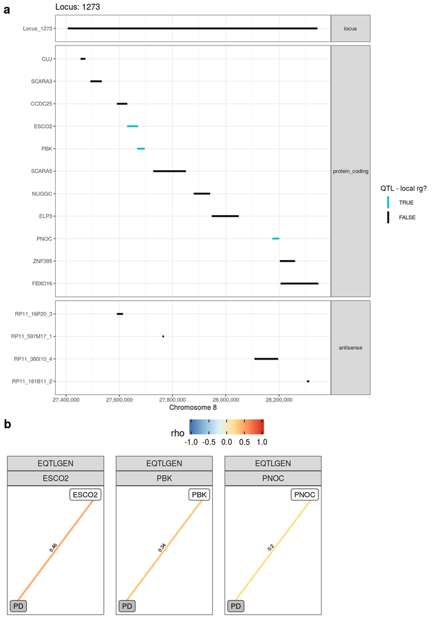

Figure 4.10: (a) Locus plot. Gene loci with a significant bivariate local genetic correlation between a disease phenotype and eQTL are highlighted in blue (Bonferroni-corrected p < 0.05). (b) Edge diagrams for gene loci where a significant bivariate local genetic correlation was observed between a disease phenotype and eQTL (Bonferroni-corrected p < 0.05). Edges display the standardised coefficient for genetic correlation (rho) for significant bivariate local genetic correlations, with negative and positive correlations indicated by blue and red colour, respectively. GWAS and eQTL nodes are indicated by grey and white fill, respectively.

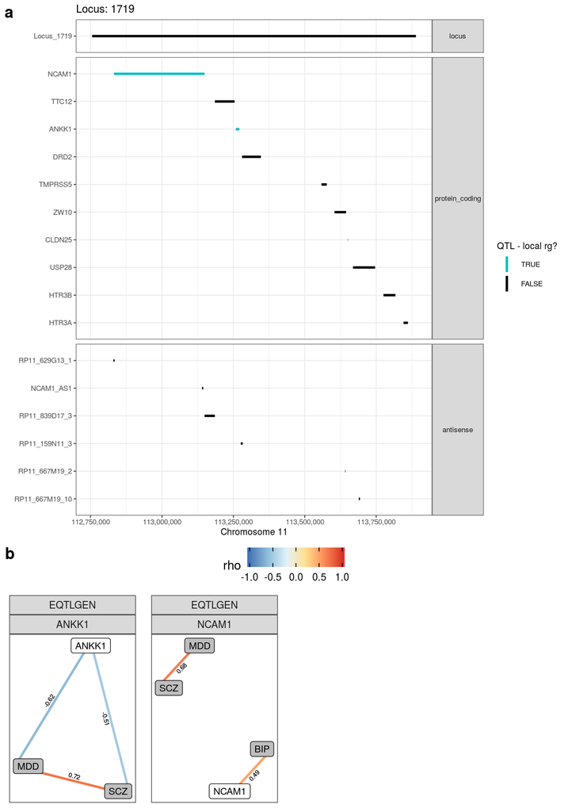

Figure 4.11: (a) Locus plot. Gene loci with a significant bivariate local genetic correlation between a disease phenotype and eQTL are highlighted in blue (Bonferroni-corrected p < 0.05). (b) Edge diagrams for gene loci where a significant bivariate local genetic correlation was observed between a disease phenotype and eQTL (Bonferroni-corrected p < 0.05). Edges display the standardised coefficient for genetic correlation (rho) for significant bivariate local genetic correlations, with negative and positive correlations indicated by blue and red colour, respectively. GWAS and eQTL nodes are indicated by grey and white fill, respectively.

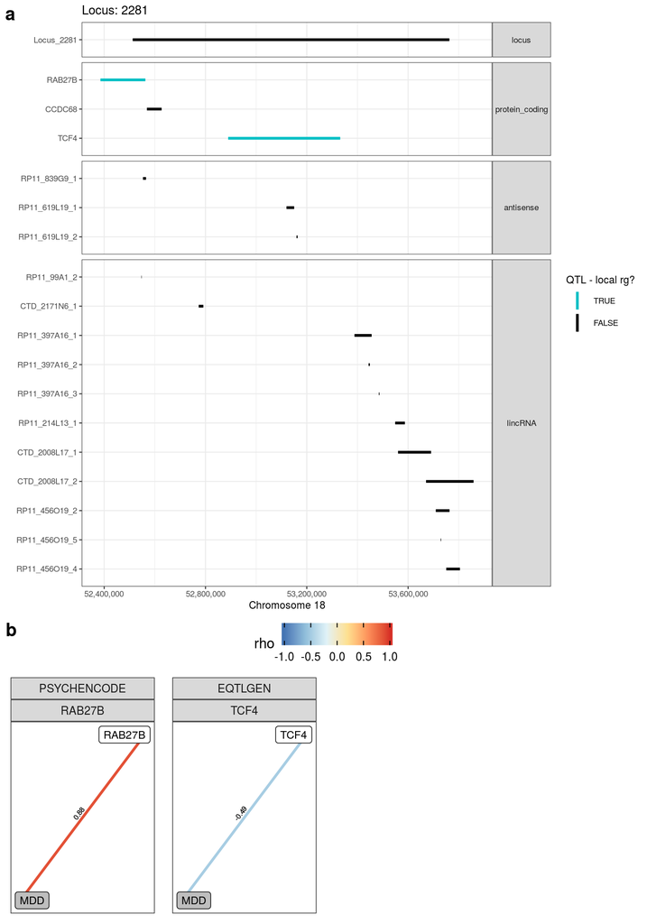

Figure 4.12: (a) Locus plot. Gene loci with a significant bivariate local genetic correlation between a disease phenotype and eQTL are highlighted in blue (Bonferroni-corrected p < 0.05). (b) Edge diagrams for gene loci where a significant bivariate local genetic correlation was observed between a disease phenotype and eQTL (Bonferroni-corrected p < 0.05). Edges display the standardised coefficient for genetic correlation (rho) for significant bivariate local genetic correlations, with negative and positive correlations indicated by blue and red colour, respectively. GWAS and eQTL nodes are indicated by grey and white fill, respectively.

```r
ld_blocks <-
  bivar_bonf %>%
  dplyr::group_by(eqtl_dataset, gene_locus) %>%
  .[["ld_block"]] %>%
  unique() %>%
  sort()

qtl_genes <-
  bivar_bonf %>%
  dplyr::group_by(eqtl_dataset, gene_locus) %>%
  dplyr::filter(str_detect(phen2, "ENSG")) %>%
  .[["gene_locus"]] %>%
  unique()

bivar_list <-
  setNames(
    bivar_bonf %>%
      dplyr::group_split(ld_block),
    nm =
      str_c("locus_", ld_blocks)
  )

fig_list <- vector(mode = "list", length = length(ld_blocks))

for(block in ld_blocks){

  locus_plot <-
    plot_locus(
    locus_gr = loci_gr[loci_gr$locus == block],
    ref = ref,
    highlight_gene = qtl_genes,
    highlight_gene_label = "QTL - local rg?"
    )

  edge_plot <-
    plot_qtl_edge_diagram(
          bivar_corr_qtl = bivar_list[[str_c("locus_", block)]],
          phen = fct_disease,
          seed = 89
        )

  if(length(edge_plot)/4 >=2){

    height <- c(1,3.5)

  } else{

    height <- c(1,0.5)
  }

  fig_list[[which(ld_blocks == block)]] <-
    ggpubr::ggarrange(
      locus_plot,
      ggpubr::ggarrange(
        plotlist = edge_plot,
        ncol = 4,
        nrow = ceiling(length(edge_plot)/4),
        common.legend = TRUE,
        legend = "top"
      ),
      ncol = 1,
      labels = letters[1:2],
      heights = height
    )

    names(fig_list)[which(ld_blocks == block)] <- str_c("locus_", block)

}

fig_list[1:4]
```

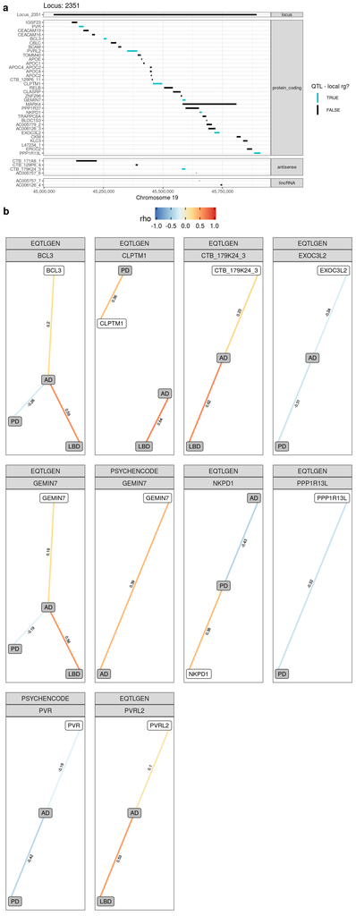

Figure 4.13: (a) Locus plot. Gene loci with a significant bivariate local genetic correlation between a disease phenotype and eQTL are highlighted in blue (Bonferroni-corrected p < 0.05). (b) Edge diagrams for gene loci where a significant bivariate local genetic correlation was observed between a disease phenotype and eQTL (Bonferroni-corrected p < 0.05). Edges display the standardised coefficient for genetic correlation (rho) for significant bivariate local genetic correlations, with negative and positive correlations indicated by blue and red colour, respectively. GWAS and eQTL nodes are indicated by grey and white fill, respectively.

```r
fig_list[5]
```